# Predykcja cen mieszkań - Raport nr 1

**Przedmiot:** Metody analizy, przetwarzania i wizualizacji danych  
**Autorzy:** Jakub Nowosad, Łukasz Iwanek, Piotr Białas  
**Data:** 09.04.2026

W ramach tego raportu zajmujemy się pierwszym etapem naszego projektu. Na ten moment chcemy:

- wybrać zbiór danych i go opisać,
- zaimportować dane do Pythona,
- sprawdzić jak wyglądają dane od środka (struktura, typy kolumn),
- zidentyfikować jakie mamy atrybuty,
- zrobić kilka wstępnych wykresów,
- napisać krótkie podsumowanie z tego co udało nam się zaobserwować.

## 1. Wybór zbioru danych

Zdecydowaliśmy się na **Ames Housing Dataset** - zbiór danych o nieruchomościach z miasta Ames w stanie Iowa (USA). Dane pochodzą z platformy [OpenML](https://www.openml.org/d/42165) i zostały pierwotnie zebrane przez prof. Deana De Cocka z Truman State University.

Dlaczego akurat ten zbiór?

- Jest dość duży (1460 rekordów) i ma sporo kolumn (80 atrybutów + cena), więc jest co analizować
- Dotyczy realnego problemu - przewidywania cen nieruchomości
- Dane są publicznie dostępne i dobrze udokumentowane
- Mamy mix różnych typów danych - liczby, kategorie, oceny jakości itp.

Każdy rekord opisuje jedną sprzedaną nieruchomość z lat 2006-2010, a atrybuty obejmują m.in. powierzchnię, liczbę pokoi, jakość wykończenia, dzielnicę czy rok budowy. Zmienna docelowa to `SalePrice` - czyli cena, za którą dom został sprzedany.

## 2. Import danych

Wczytujemy dane z pliku CSV do pandas. Korzystamy też z matplotlib i seaborn do wykresów.

```
Loaded 1460 rows, 81 columns
```

|  | Id | MSSubClass | MSZoning | LotFrontage | LotArea | Street | Alley | LotShape | LandContour | Utilities | ... | PoolArea | PoolQC | Fence | MiscFeature | MiscVal | MoSold | YrSold | SaleType | SaleCondition | SalePrice |
| --- | --- | --- | --- | --- | --- | --- | --- | --- | --- | --- | --- | --- | --- | --- | --- | --- | --- | --- | --- | --- | --- |
| 0 | 1 | 60 | RL | 65.0 | 8450 | Pave | NaN | Reg | Lvl | AllPub | ... | 0 | NaN | NaN | NaN | 0 | 2 | 2008 | WD | Normal | 208500 |
| 1 | 2 | 20 | RL | 80.0 | 9600 | Pave | NaN | Reg | Lvl | AllPub | ... | 0 | NaN | NaN | NaN | 0 | 5 | 2007 | WD | Normal | 181500 |
| 2 | 3 | 60 | RL | 68.0 | 11250 | Pave | NaN | IR1 | Lvl | AllPub | ... | 0 | NaN | NaN | NaN | 0 | 9 | 2008 | WD | Normal | 223500 |
| 3 | 4 | 70 | RL | 60.0 | 9550 | Pave | NaN | IR1 | Lvl | AllPub | ... | 0 | NaN | NaN | NaN | 0 | 2 | 2006 | WD | Abnorml | 140000 |
| 4 | 5 | 60 | RL | 84.0 | 14260 | Pave | NaN | IR1 | Lvl | AllPub | ... | 0 | NaN | NaN | NaN | 0 | 12 | 2008 | WD | Normal | 250000 |

5 rows × 81 columns

## 3. Struktura danych

Sprawdźmy co mamy w środku - ile kolumn, jakie typy, czy są jakieś braki.

```
<class 'pandas.DataFrame'>
RangeIndex: 1460 entries, 0 to 1459
Data columns (total 81 columns):
 #   Column         Non-Null Count  Dtype
---  ------         --------------  -----
 0   Id             1460 non-null   int64
 1   MSSubClass     1460 non-null   int64
 2   MSZoning       1460 non-null   str
 3   LotFrontage    1201 non-null   float64
 4   LotArea        1460 non-null   int64
 5   Street         1460 non-null   str
 6   Alley          91 non-null     str
 7   LotShape       1460 non-null   str
 8   LandContour    1460 non-null   str
 9   Utilities      1460 non-null   str
```

[output cut: 73 more lines]

|  | Id | MSSubClass | LotFrontage | LotArea | OverallQual | OverallCond | YearBuilt | YearRemodAdd | MasVnrArea | BsmtFinSF1 | ... | WoodDeckSF | OpenPorchSF | EnclosedPorch | 3SsnPorch | ScreenPorch | PoolArea | MiscVal | MoSold | YrSold | SalePrice |
| --- | --- | --- | --- | --- | --- | --- | --- | --- | --- | --- | --- | --- | --- | --- | --- | --- | --- | --- | --- | --- | --- |
| count | 1460.00 | 1460.0 | 1201.00 | 1460.00 | 1460.00 | 1460.00 | 1460.00 | 1460.00 | 1452.00 | 1460.00 | ... | 1460.00 | 1460.00 | 1460.00 | 1460.00 | 1460.00 | 1460.00 | 1460.00 | 1460.00 | 1460.00 | 1460.0 |
| mean | 730.50 | 56.9 | 70.05 | 10516.83 | 6.10 | 5.58 | 1971.27 | 1984.87 | 103.69 | 443.64 | ... | 94.24 | 46.66 | 21.95 | 3.41 | 15.06 | 2.76 | 43.49 | 6.32 | 2007.82 | 180921.2 |
| std | 421.61 | 42.3 | 24.28 | 9981.26 | 1.38 | 1.11 | 30.20 | 20.65 | 181.07 | 456.10 | ... | 125.34 | 66.26 | 61.12 | 29.32 | 55.76 | 40.18 | 496.12 | 2.70 | 1.33 | 79442.5 |
| min | 1.00 | 20.0 | 21.00 | 1300.00 | 1.00 | 1.00 | 1872.00 | 1950.00 | 0.00 | 0.00 | ... | 0.00 | 0.00 | 0.00 | 0.00 | 0.00 | 0.00 | 0.00 | 1.00 | 2006.00 | 34900.0 |
| 25% | 365.75 | 20.0 | 59.00 | 7553.50 | 5.00 | 5.00 | 1954.00 | 1967.00 | 0.00 | 0.00 | ... | 0.00 | 0.00 | 0.00 | 0.00 | 0.00 | 0.00 | 0.00 | 5.00 | 2007.00 | 129975.0 |
| 50% | 730.50 | 50.0 | 69.00 | 9478.50 | 6.00 | 5.00 | 1973.00 | 1994.00 | 0.00 | 383.50 | ... | 0.00 | 25.00 | 0.00 | 0.00 | 0.00 | 0.00 | 0.00 | 6.00 | 2008.00 | 163000.0 |
| 75% | 1095.25 | 70.0 | 80.00 | 11601.50 | 7.00 | 6.00 | 2000.00 | 2004.00 | 166.00 | 712.25 | ... | 168.00 | 68.00 | 0.00 | 0.00 | 0.00 | 0.00 | 0.00 | 8.00 | 2009.00 | 214000.0 |
| max | 1460.00 | 190.0 | 313.00 | 215245.00 | 10.00 | 9.00 | 2010.00 | 2010.00 | 1600.00 | 5644.00 | ... | 857.00 | 547.00 | 552.00 | 508.00 | 480.00 | 738.00 | 15500.00 | 12.00 | 2010.00 | 755000.0 |

8 rows × 38 columns

|  | MSZoning | Street | Alley | LotShape | LandContour | Utilities | LotConfig | LandSlope | Neighborhood | Condition1 | ... | GarageType | GarageFinish | GarageQual | GarageCond | PavedDrive | PoolQC | Fence | MiscFeature | SaleType | SaleCondition |
| --- | --- | --- | --- | --- | --- | --- | --- | --- | --- | --- | --- | --- | --- | --- | --- | --- | --- | --- | --- | --- | --- |
| count | 1460 | 1460 | 91 | 1460 | 1460 | 1460 | 1460 | 1460 | 1460 | 1460 | ... | 1379 | 1379 | 1379 | 1379 | 1460 | 7 | 281 | 54 | 1460 | 1460 |
| unique | 5 | 2 | 2 | 4 | 4 | 2 | 5 | 3 | 25 | 9 | ... | 6 | 3 | 5 | 5 | 3 | 3 | 4 | 4 | 9 | 6 |
| top | RL | Pave | Grvl | Reg | Lvl | AllPub | Inside | Gtl | NAmes | Norm | ... | Attchd | Unf | TA | TA | Y | Gd | MnPrv | Shed | WD | Normal |
| freq | 1151 | 1454 | 50 | 925 | 1311 | 1459 | 1052 | 1382 | 225 | 1260 | ... | 870 | 605 | 1311 | 1326 | 1340 | 3 | 157 | 49 | 1267 | 1198 |

4 rows × 43 columns

## 4. Identyfikacja atrybutów

Podzielmy sobie kolumny na typy - numeryczne, kategoryczne (tekstowe) i binarne (tylko 2 wartości).

```
Numeric (38): ['Id', 'MSSubClass', 'LotFrontage', 'LotArea', 'OverallQual', 'OverallCond', 'YearBuilt', 'YearRemodAdd', 'MasVnrArea', 'BsmtFinSF1', 'BsmtFinSF2', 'BsmtUnfSF', 'TotalBsmtSF', '1stFlrSF', '2ndFlrSF', 'LowQualFinSF', 'GrLivArea', 'BsmtFullBath', 'BsmtHalfBath', 'FullBath', 'HalfBath', '…

Categorical (43): ['MSZoning', 'Street', 'Alley', 'LotShape', 'LandContour', 'Utilities', 'LotConfig', 'LandSlope', 'Neighborhood', 'Condition1', 'Condition2', 'BldgType', 'HouseStyle', 'RoofStyle', 'RoofMatl', 'Exterior1st', 'Exterior2nd', 'MasVnrType', 'ExterQual', 'ExterCond', 'Foundation', 'Bsmt…

Binary (4): ['Street', 'Alley', 'Utilities', 'CentralAir']
```

### Braki w danych

Ważna rzecz - sprawdźmy które kolumny mają brakujące wartości i ile tego jest.

```
Columns with missing data: 19 / 81
```

|  | Missing | Percent [%] |
| --- | --- | --- |
| PoolQC | 1453 | 99.5 |
| MiscFeature | 1406 | 96.3 |
| Alley | 1369 | 93.8 |
| Fence | 1179 | 80.8 |
| MasVnrType | 872 | 59.7 |
| FireplaceQu | 690 | 47.3 |
| LotFrontage | 259 | 17.7 |
| GarageType | 81 | 5.5 |
| GarageYrBlt | 81 | 5.5 |
| GarageFinish | 81 | 5.5 |
| GarageQual | 81 | 5.5 |
| GarageCond | 81 | 5.5 |
| BsmtFinType2 | 38 | 2.6 |
| BsmtExposure | 38 | 2.6 |
| BsmtFinType1 | 37 | 2.5 |
| BsmtCond | 37 | 2.5 |
| BsmtQual | 37 | 2.5 |
| MasVnrArea | 8 | 0.5 |
| Electrical | 1 | 0.1 |

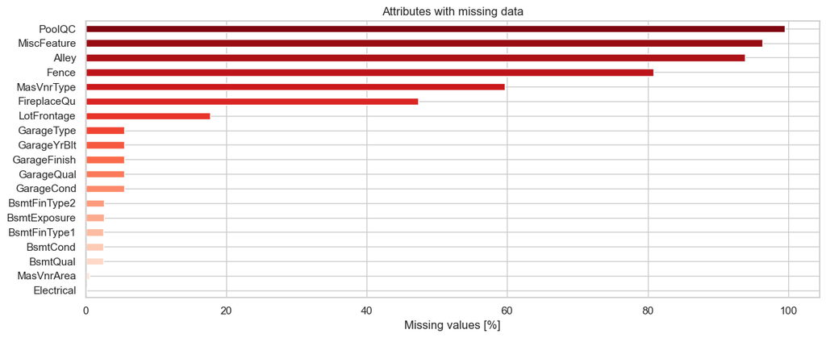

## 5. Wstępne wizualizacje

Czas na wykresy. Zaczniemy od tego jak wyglądają ceny, potem sprawdzimy co najbardziej wpływa na cenę.

### 5.1 Jak rozkładają się ceny?

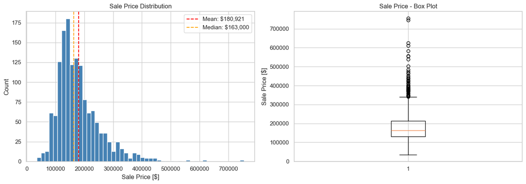

```
Mean:   $  180,921.20
Median: $  163,000.00
Min:    $   34,900.00
Max:    $  755,000.00
Std:    $   79,442.50
```

### 5.2 Które atrybuty najbardziej korelują z ceną?

Policzyliśmy korelację Pearsona dla wszystkich atrybutów numerycznych i wybraliśmy top 15.

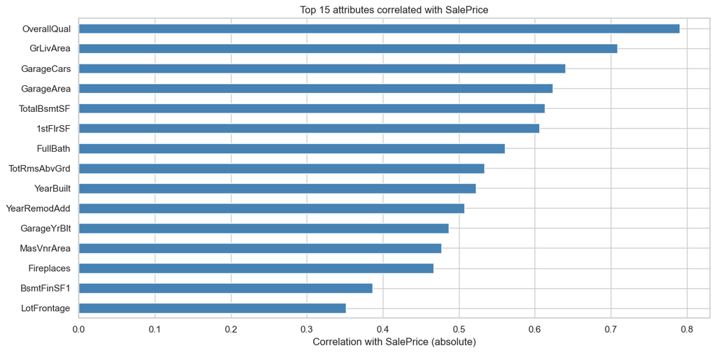

### 5.3 Macierz korelacji

Heatmapa dla 10 atrybutów najsilniej powiązanych z ceną - dzięki temu widać też zależności między samymi atrybutami.

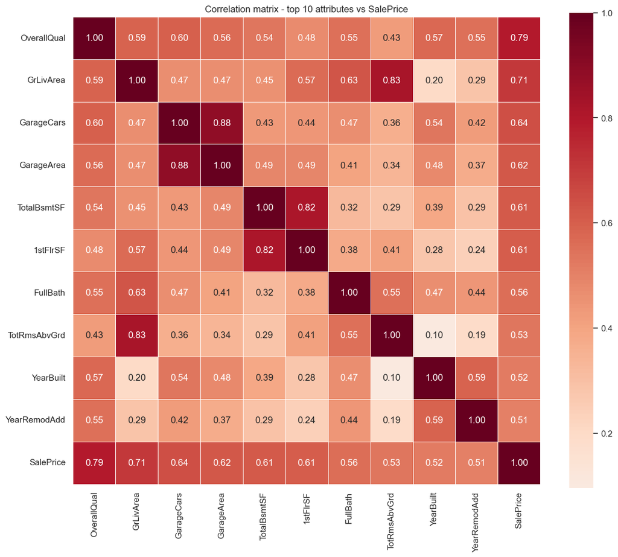

### 5.4 Wykresy rozrzutu

Zobaczmy na wykresach jak wyglądają zależności między 4 najlepszymi atrybutami a ceną.

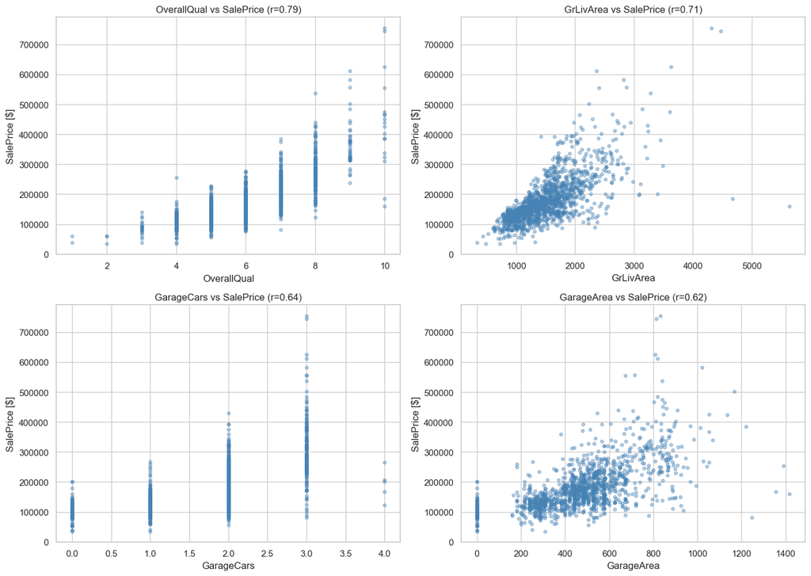

### 5.5 Ceny w różnych dzielnicach

Sprawdzamy czy lokalizacja ma duże znaczenie.

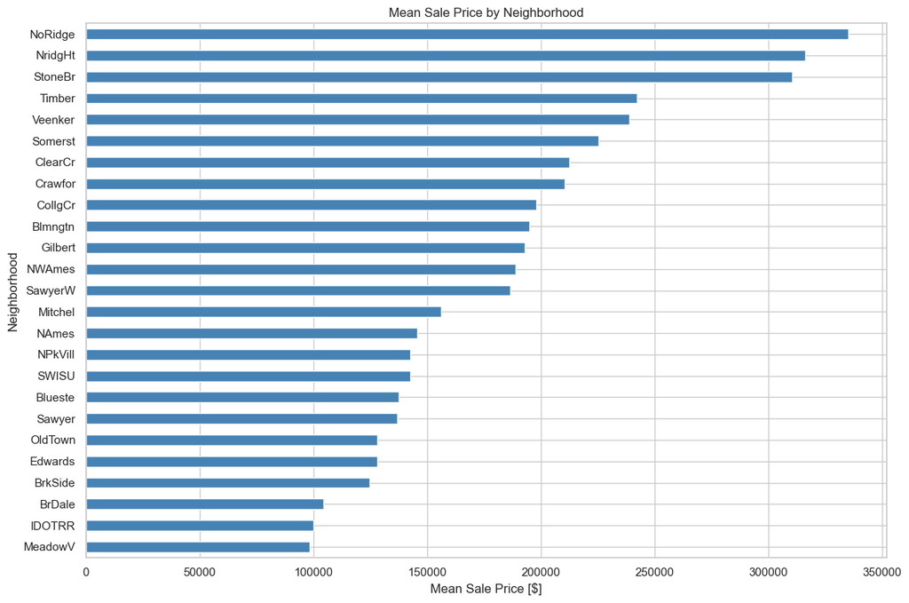

### 5.6 Jakość wykończenia a cena

OverallQual to ocena ogólnej jakości materiałów i wykończenia domu (skala 1-10). Zobaczmy jak przekłada się na cenę.

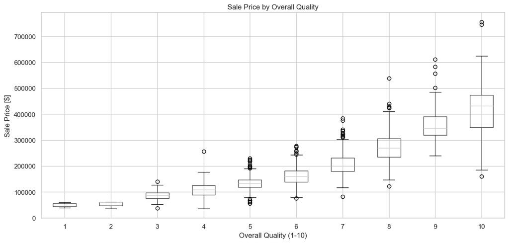

### 5.7 Kiedy ludzie kupują domy?

Sprawdzimy czy jest jakaś sezonowość w sprzedaży.

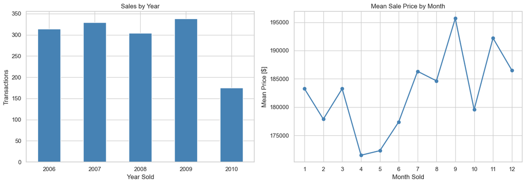

## 6. Podsumowanie

### Co mamy w zbiorze?

Nasz dataset to 1460 domów z 80 atrybutami. Jest w tym 37 kolumn numerycznych (powierzchnie, liczba pokoi, oceny, daty) i 43 kategoryczne (dzielnica, typ budynku, materiały itd.). 4 atrybuty są binarne (np. czy jest klimatyzacja).

### Problem z brakami

19 kolumn ma brakujące wartości. Największe braki to PoolQC (99.5%), MiscFeature (96.3%) i Alley (93.8%). Warto zauważyć, że większość tych braków to po prostu informacja, że dany element nie istnieje - np. brak wartości w PoolQC oznacza, że dom nie ma basenu. To trzeba będzie odpowiednio obsłużyć przy przetwarzaniu.

### Co dalej?

W następnym etapie zajmiemy się:

- czyszczeniem danych (uzupełnienie braków, usunięcie outlierów),
- zakodowaniem zmiennych kategorycznych,
- normalizacją danych,
- a potem spróbujemy zbudować pierwsze modele predykcyjne.